# FracFocus Data Analysis

## Index

- Correlation between different variables in the dataset using Pairplot and Heatmap
- Ingredients and their PercentHFJob and PercentHighAdditive
- Ingredients and their Purpose
- Hydraulic Fracturing Jobs across different States
- Most Frequently Contracted Suppliers for Fracturing jobs
- Time Analysis across some Registries
- Plotting all the Federal and Indian Wells using Geopandas
- Ingredients used across various locations
- Calculation of Volume based on ingredients

```python
# Importing libraries
import pandas as pd
import matplotlib.pyplot as plt
import seaborn as sns

import warnings

import geopandas as gpd
from shapely.geometry import Point, Polygon
```

```python
# Reading all the required datasets

df_ffr1 = pd.read_csv("FracFocusRegistry_1.csv")
df_ffr2 = pd.read_csv("FracFocusRegistry_2.csv")
df_ffr3 = pd.read_csv("FracFocusRegistry_3.csv")
df_ffr4 = pd.read_csv("FracFocusRegistry_4.csv")
df_ffr5 = pd.read_csv("FracFocusRegistry_5.csv")
df_ffr6 = pd.read_csv("FracFocusRegistry_6.csv")
df_ffr7 = pd.read_csv("FracFocusRegistry_7.csv")
df_ffr8 = pd.read_csv("FracFocusRegistry_8.csv")
df_ffr9 = pd.read_csv("FracFocusRegistry_9.csv")
df_ffr10 = pd.read_csv("FracFocusRegistry_10.csv")
df_ffr11 = pd.read_csv("FracFocusRegistry_11.csv")
df_ffr12 = pd.read_csv("FracFocusRegistry_12.csv")
df_ffr13 = pd.read_csv("FracFocusRegistry_13.csv")
df_ffr14 = pd.read_csv("FracFocusRegistry_14.csv")
df_ffr15 = pd.read_csv("FracFocusRegistry_15.csv")
df_ffr16 = pd.read_csv("FracFocusRegistry_16.csv")
df_ffr17 = pd.read_csv("FracFocusRegistry_17.csv")
df_ffr18 = pd.read_csv("FracFocusRegistry_18.csv")

warnings.filterwarnings("ignore")
```

```python
# Combining these datasets
df_ffr = pd.concat([df_ffr1, df_ffr2, df_ffr3, df_ffr4, df_ffr5, df_ffr6, df_ffr7,
                    df_ffr8, df_ffr9, df_ffr10, df_ffr11, df_ffr12, df_ffr13, df_ffr14,
                    df_ffr15, df_ffr16, df_ffr17, df_ffr18], ignore_index=True)
```

```python
# Looking into the dataset

df_ffr.info()
```

```
<class 'pandas.core.frame.DataFrame'>
RangeIndex: 4346212 entries, 0 to 4346211
Data columns (total 39 columns):
UploadKey                  object
JobStartDate               object
JobEndDate                 object
APINumber                  int64
StateNumber                int64
CountyNumber               int64
OperatorName               object
WellName                   object
Latitude                   float64
Longitude                  float64
Projection                 object
TVD                        float64
TotalBaseWaterVolume       float64
TotalBaseNonWaterVolume    float64
StateName                  object
CountyName                 object
FFVersion                  int64
FederalWell                bool
IndianWell                 bool
Source                     float64
DTMOD                      float64
PurposeKey                 object
TradeName                  object
Supplier                   object
Purpose                    object
SystemApproach             float64
IsWater                    float64
PurposePercentHFJob        float64
PurposeIngredientMSDS      float64
IngredientKey              object
IngredientName             object
CASNumber                  object
PercentHighAdditive        float64
PercentHFJob               float64
IngredientComment          object
IngredientMSDS             object
MassIngredient             float64
ClaimantCompany            object
DisclosureKey              object
dtypes: bool(2), float64(14), int64(4), object(19)
memory usage: 1.2+ GB
```

```python
df_ffr1.info()
```

```
<class 'pandas.core.frame.DataFrame'>
RangeIndex: 250000 entries, 0 to 249999
Data columns (total 39 columns):
UploadKey                  250000 non-null object
JobStartDate               250000 non-null object
JobEndDate                 250000 non-null object
APINumber                  250000 non-null int64
StateNumber                250000 non-null int64
CountyNumber               250000 non-null int64
OperatorName               250000 non-null object
WellName                   250000 non-null object
Latitude                   250000 non-null float64
Longitude                  250000 non-null float64
Projection                 250000 non-null object
TVD                        189719 non-null float64
TotalBaseWaterVolume       189675 non-null float64
TotalBaseNonWaterVolume    121805 non-null float64
StateName                  249996 non-null object
CountyName                 249992 non-null object
FFVersion                  250000 non-null int64
FederalWell                250000 non-null bool
IndianWell                 250000 non-null bool
Source                     0 non-null float64
DTMOD                      0 non-null float64
PurposeKey                 163507 non-null object
TradeName                  134352 non-null object
Supplier                   135736 non-null object
Purpose                    159134 non-null object
SystemApproach             0 non-null float64
IsWater                    0 non-null float64
PurposePercentHFJob        0 non-null float64
PurposeIngredientMSDS      0 non-null float64
IngredientKey              163667 non-null object
IngredientName             163598 non-null object
CASNumber                  160072 non-null object
PercentHighAdditive        162316 non-null float64
PercentHFJob               162197 non-null float64
IngredientComment          20260 non-null object
IngredientMSDS             163667 non-null object
MassIngredient             160546 non-null float64
ClaimantCompany            18 non-null object
DisclosureKey              163667 non-null object
dtypes: bool(2), float64(14), int64(4), object(19)
memory usage: 71.0+ MB
```

```python
df_ffr2.info()
```

```
<class 'pandas.core.frame.DataFrame'>
RangeIndex: 250000 entries, 0 to 249999
Data columns (total 39 columns):
UploadKey                  250000 non-null object
JobStartDate               250000 non-null object
JobEndDate                 250000 non-null object
APINumber                  250000 non-null int64
StateNumber                250000 non-null int64
CountyNumber               250000 non-null int64
OperatorName               250000 non-null object
WellName                   250000 non-null object
Latitude                   250000 non-null float64
Longitude                  250000 non-null float64
Projection                 250000 non-null object
TVD                        250000 non-null float64
TotalBaseWaterVolume       250000 non-null float64
TotalBaseNonWaterVolume    203866 non-null float64
StateName                  250000 non-null object
CountyName                 250000 non-null object
FFVersion                  250000 non-null int64
FederalWell                250000 non-null bool
IndianWell                 250000 non-null bool
Source                     0 non-null float64
DTMOD                      0 non-null float64
PurposeKey                 248573 non-null object
TradeName                  198416 non-null object
Supplier                   198452 non-null object
Purpose                    236616 non-null object
SystemApproach             0 non-null float64
IsWater                    0 non-null float64
PurposePercentHFJob        0 non-null float64
PurposeIngredientMSDS      0 non-null float64
IngredientKey              248684 non-null object
IngredientName             248643 non-null object
CASNumber                  243480 non-null object
PercentHighAdditive        248518 non-null float64
PercentHFJob               248326 non-null float64
IngredientComment          42612 non-null object
IngredientMSDS             248684 non-null object
MassIngredient             248186 non-null float64
ClaimantCompany            24 non-null object
DisclosureKey              248684 non-null object
dtypes: bool(2), float64(14), int64(4), object(19)
memory usage: 71.0+ MB
```

```python
df_ffr17.info()
```

```
<class 'pandas.core.frame.DataFrame'>
RangeIndex: 250000 entries, 0 to 249999
Data columns (total 39 columns):
UploadKey                  250000 non-null object
JobStartDate               249980 non-null object
JobEndDate                 250000 non-null object
APINumber                  250000 non-null int64
StateNumber                250000 non-null int64
CountyNumber               250000 non-null int64
OperatorName               250000 non-null object
WellName                   250000 non-null object
Latitude                   250000 non-null float64
Longitude                  250000 non-null float64
Projection                 250000 non-null object
TVD                        250000 non-null float64
TotalBaseWaterVolume       250000 non-null float64
TotalBaseNonWaterVolume    244549 non-null float64
StateName                  250000 non-null object
CountyName                 250000 non-null object
FFVersion                  250000 non-null int64
FederalWell                250000 non-null bool
IndianWell                 250000 non-null bool
Source                     0 non-null float64
DTMOD                      0 non-null float64
PurposeKey                 139460 non-null object
TradeName                  136185 non-null object
Supplier                   136168 non-null object
Purpose                    139217 non-null object
SystemApproach             0 non-null float64
IsWater                    0 non-null float64
PurposePercentHFJob        0 non-null float64
PurposeIngredientMSDS      0 non-null float64
IngredientKey              249980 non-null object
IngredientName             249965 non-null object
CASNumber                  249980 non-null object
PercentHighAdditive        243666 non-null float64
PercentHFJob               243630 non-null float64
IngredientComment          54377 non-null object
IngredientMSDS             249980 non-null object
MassIngredient             241784 non-null float64
ClaimantCompany            18014 non-null object
DisclosureKey              249980 non-null object
dtypes: bool(2), float64(14), int64(4), object(19)
memory usage: 71.0+ MB
```

```python
# All the above 3 datasets have following columns with null values
# Source                     0 non-null float64
# DTMOD                      0 non-null float64
# SystemApproach             0 non-null float64
# IsWater                    0 non-null float64
# PurposePercentHFJob        0 non-null float64
# PurposeIngredientMSDS      0 non-null float64
# These can be easily omitted

# PurposeKey                 is primary key
# UploadKey                  is pk
# IngredientKey              is pk
# These can be omitted

# IngredientMSDS
# MassIngredient
# DisclosureKey
# These are unexplained in readme, but have significant data
```

### Correlation between different variables in the dataset using Pairplot and Heatmap

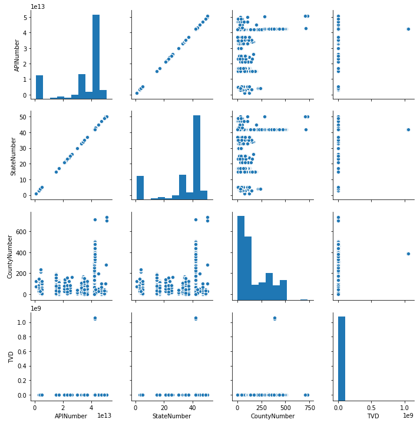

```python
# Finding correaltion using pairplot
# Only considering Registry 1 for faster processing

sns.pairplot(df_ffr1[["APINumber","StateNumber","CountyNumber","TVD"]])
plt.figure(figsize=(40,40))
plt.show()
```

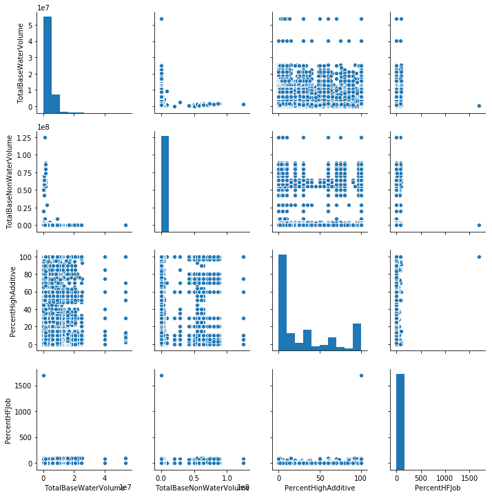

```python
# Finding correaltion using pairplot
# Only considering Registry 1 for faster processing

sns.pairplot(df_ffr1[["TotalBaseWaterVolume","TotalBaseNonWaterVolume","PercentHighAdditive","PercentHFJob"]])
plt.figure(figsize=(40,40))
plt.show()
```

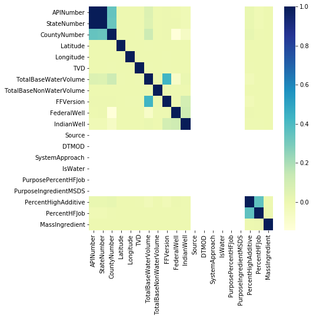

```python
# Finding correaltion using heatmap

corr = df_ffr.corr()

fig, ax = plt.subplots(figsize=(7,7))
sns.heatmap(corr,
            xticklabels=corr.columns.values,
            yticklabels=corr.columns.values, ax=ax, cmap="YlGnBu")
plt.show()
```

### Ingredients and their PercentHFJob and PercentHighAdditive

Based on the correlation heatmap, we will first find out realtionship between PercentHFJob and PercentHighAdditive. This can be achived by finding both of the feature's individual relationship with their ingredients.  
Only the top 20 ingredients will be considered for both the cases.  
Since IngredientName contains messy data, it is cleaned by the following manner:

```python
# Caplitalizing the Ingredient Names in order to avoid duplicate enrties

df_ffr['IngredientName'] = df_ffr['IngredientName'].str.capitalize()
```

```python
# Finding out relationship between Ingredients with PercentHFJob

df_ffr.groupby(['IngredientName'])['PercentHFJob'].describe().sort_values(by = 'count', ascending = False).head(20)
```

| IngredientName | count | mean | std | min | 25% | 50% | 75% | max |
| --- | --- | --- | --- | --- | --- | --- | --- | --- |
| Water | 336929.0 | 21.656867 | 37.281766 | 0.0 | 0.010253 | 0.075120 | 27.085398 | 1691.154881 |
| Listed below | 128354.0 | 0.000494 | 0.085828 | 0.0 | 0.000000 | 0.000000 | 0.000000 | 16.423207 |
| Methanol | 113949.0 | 0.064116 | 1.424788 | 0.0 | 0.000291 | 0.001595 | 0.009275 | 100.000000 |
| Sodium chloride | 72145.0 | 0.076777 | 1.148235 | 0.0 | 0.000736 | 0.002910 | 0.009640 | 100.000000 |
| Hydrochloric acid | 68664.0 | 0.266379 | 1.654480 | 0.0 | 0.021168 | 0.079577 | 0.193622 | 100.000000 |
| Ethylene glycol | 63235.0 | 0.037934 | 0.670750 | 0.0 | 0.000759 | 0.004669 | 0.018284 | 85.260924 |
| Crystalline silica, quartz | 59825.0 | 6.748915 | 8.521831 | 0.0 | 0.003266 | 5.041153 | 11.173244 | 98.394227 |
| Guar gum | 55573.0 | 0.168114 | 0.876850 | 0.0 | 0.035436 | 0.117946 | 0.204833 | 55.000000 |
| Sodium hydroxide | 52030.0 | 0.014821 | 0.132589 | 0.0 | 0.000280 | 0.003925 | 0.013939 | 15.318410 |
| Isopropanol | 42734.0 | 0.022214 | 0.488905 | 0.0 | 0.000094 | 0.000662 | 0.008231 | 50.000000 |
| Acetic acid | 40665.0 | 0.011938 | 0.483901 | 0.0 | 0.000583 | 0.001901 | 0.005040 | 64.334160 |
| Ethanol | 38534.0 | 0.021034 | 0.394145 | 0.0 | 0.000300 | 0.001042 | 0.024311 | 31.150000 |
| Ammonium chloride | 37081.0 | 0.006074 | 0.071103 | 0.0 | 0.000775 | 0.002294 | 0.005776 | 10.000000 |
| Ammonium persulfate | 36355.0 | 0.026108 | 1.133514 | 0.0 | 0.001095 | 0.003354 | 0.007702 | 100.000000 |
| Proprietary | 35868.0 | 0.029032 | 0.806879 | 0.0 | 0.000436 | 0.003399 | 0.013973 | 60.000000 |
| Glutaraldehyde | 33560.0 | 0.088709 | 1.244804 | 0.0 | 0.002726 | 0.005221 | 0.008440 | 93.000000 |
| Potassium hydroxide | 31997.0 | 0.011082 | 0.158357 | 0.0 | 0.000732 | 0.002754 | 0.012580 | 25.000000 |
| Citric acid | 31268.0 | 0.030389 | 1.249200 | 0.0 | 0.000493 | 0.001320 | 0.003670 | 100.000000 |
| Propargyl alcohol | 31160.0 | 0.003568 | 0.547934 | 0.0 | 0.000042 | 0.000121 | 0.000276 | 96.717560 |
| Methyl alcohol | 23676.0 | 0.017113 | 0.716441 | 0.0 | 0.000313 | 0.001751 | 0.009382 | 100.000000 |

```python
# Finding out relationship between Ingredients with PercentHighAdditive

df_ffr.groupby(['IngredientName'])['PercentHighAdditive'].describe().sort_values(by = 'count', ascending = False).head(20)
```

| IngredientName | count | mean | std | min | 25% | 50% | 75% | max |
| --- | --- | --- | --- | --- | --- | --- | --- | --- |
| Water | 337131.0 | 66.908841 | 35.290598 | 0.0 | 48.00000 | 80.0 | 100.0 | 100.0 |
| Listed below | 128354.0 | 0.002474 | 0.380730 | 0.0 | 0.00000 | 0.0 | 0.0 | 100.0 |
| Methanol | 113930.0 | 36.175439 | 29.810571 | 0.0 | 10.00000 | 30.0 | 60.0 | 100.0 |
| Sodium chloride | 72177.0 | 11.779810 | 17.698985 | 0.0 | 0.00000 | 5.0 | 15.0 | 100.0 |
| Hydrochloric acid | 68676.0 | 22.020098 | 20.186142 | 0.0 | 10.00000 | 15.0 | 30.0 | 100.0 |
| Ethylene glycol | 63283.0 | 28.059947 | 19.543418 | 0.0 | 10.00000 | 30.0 | 40.0 | 100.0 |
| Crystalline silica, quartz | 59828.0 | 74.384858 | 42.057956 | 0.0 | 30.00000 | 100.0 | 100.0 | 100.0 |
| Guar gum | 55584.0 | 57.977755 | 36.291037 | 0.0 | 48.00000 | 55.0 | 100.0 | 100.0 |
| Sodium hydroxide | 52054.0 | 16.000948 | 18.307612 | 0.0 | 1.00000 | 5.0 | 30.0 | 100.0 |
| Isopropanol | 42739.0 | 21.375472 | 17.950584 | 0.0 | 5.00000 | 25.0 | 30.0 | 100.0 |
| Acetic acid | 40679.0 | 39.797468 | 28.353481 | 0.0 | 10.00000 | 38.0 | 60.0 | 100.0 |
| Ethanol | 38552.0 | 23.365830 | 26.310959 | 0.0 | 3.00000 | 5.0 | 60.0 | 100.0 |
| Ammonium chloride | 37081.0 | 7.104944 | 9.554827 | 0.0 | 0.00046 | 2.0 | 12.0 | 100.0 |
| Ammonium persulfate | 36363.0 | 85.694086 | 28.504571 | 0.0 | 77.00000 | 100.0 | 100.0 | 100.0 |
| Proprietary | 35888.0 | 29.158961 | 35.214271 | 0.0 | 3.00000 | 15.0 | 46.0 | 100.0 |
| Glutaraldehyde | 33581.0 | 19.586161 | 14.371311 | 0.0 | 10.00000 | 15.7 | 30.0 | 100.0 |
| Potassium hydroxide | 32014.0 | 13.927028 | 13.240706 | 0.0 | 5.00000 | 10.0 | 25.0 | 100.0 |
| Citric acid | 31274.0 | 47.519799 | 24.588669 | 0.0 | 30.00000 | 55.0 | 60.0 | 100.0 |
| Propargyl alcohol | 31167.0 | 8.054004 | 5.869267 | 0.0 | 5.00000 | 10.0 | 10.0 | 100.0 |
| Methyl alcohol | 23733.0 | 31.081360 | 24.664305 | 0.0 | 10.00000 | 30.0 | 50.0 | 100.0 |

```python
# Determining correlation between PercentHFJob and PercentHighAdditive

round(df_ffr['PercentHighAdditive'].corr(df_ffr['PercentHFJob']),4)
```

```
0.3591
```

There is a similar trend in which the oil and gas wells which use the top 20 frequently occurring ingredients. Even the Percentages in HFJob and High Additive show similar trend as shown above.

### Ingredients and their Purpose

Now we will determine for which most frequently used purposes are the top ingredients used. This data can be highly informative for users to know what could be the actual reason behind using any ingredient.  
Note that it simply shows the purpose for those ingredients just based on frequency and there could be other reasons why a particular ingredient is used for.

```python
# Determining ingredients and their most frequent purposes

df_ffr.groupby(['IngredientName'])['Purpose'].describe().sort_values(by = 'count', ascending = False).head(20)
```

| IngredientName | count | freq | top | unique |
| --- | --- | --- | --- | --- |
| Water | 324671 | 32485 | Carrier/Base Fluid | 1525 |
| Listed below | 128277 | 18188 | Proppant | 251 |
| Methanol | 96691 | 16344 | Corrosion Inhibitor | 1956 |
| Sodium chloride | 57260 | 9518 | Other Ingredient(s) | 1237 |
| Ethylene glycol | 54163 | 8630 | Crosslinker | 956 |
| Hydrochloric acid | 52023 | 11329 | Acidizing | 1205 |
| Crystalline silica, quartz | 47359 | 21155 | Proppant | 249 |
| Guar gum | 45128 | 16074 | Gelling Agent | 1811 |
| Sodium hydroxide | 41666 | 4737 | pH Control Additive | 1427 |
|  | 38438 | 4067 | Biocide | 905 |
| Isopropanol | 35256 | 6220 | Corrosion Inhibitor | 597 |
| Acetic acid | 34831 | 5973 | Iron Control | 1184 |
| Ammonium persulfate | 32333 | 10258 | Breaker | 369 |
| Proprietary | 31687 | 11045 | Other Ingredients | 221 |
| Ethanol | 28944 | 8748 | Biocide | 563 |
| Potassium hydroxide | 28253 | 9673 | Crosslinker | 716 |
| Ammonium chloride | 28036 | 6735 | Other Ingredient(s) | 1051 |
| Citric acid | 26577 | 10304 | Iron Control | 179 |
| Propargyl alcohol | 25250 | 10158 | Corrosion Inhibitor | 664 |
| Glutaraldehyde | 24786 | 13495 | Biocide | 1048 |

### Hydraulic Fracturing Jobs across different States

Now, determing Statewise Hydraulic Fracturing jobs that took place over all the years in all the datasets.  
The states could have been directly determined from the attribute StateName but since the entries for this feature contained a lot of spelling mistakes and different name formats eg. two character state name were used and the whole state name was also used.  
But to carry out analysis efficiently, these names were determined from the StateNumber column of the dataset.  
The state numbers were obtained from the mappings provided by Wikipedia on different API Well Numbers.

```python
# Mapping State Numbers to State Names, creating an additional column called DerivedStateName

State_Code = {
1: 'Alabama',
2: 'Arizona',
3: 'Arkansas',
4: 'California',
5: 'Colorado',
6: 'Connecticut',
7: 'Delaware',
8: 'District of Columbia',
9: 'Florida',
10: 'Georgia',
11: 'Idaho',
12: 'Illinois',
13: 'Indiana',
14: 'Iowa',
15: 'Kansas',
16: 'Kentucky',
17: 'Louisiana',
18: 'Maine',
19: 'Maryland',
20: 'Massachusetts',
21: 'Michigan',
22: 'Minnesota',
23: 'Mississippi',
24: 'Missouri',
25: 'Montana',
26: 'Nebraska',
27: 'Nevada',
28: 'New Hampshire',
29: 'New Jersey',
30: 'New Mexico',
31: 'New York',
32: 'North Carolina',
33: 'North Dakota',
34: 'Ohio',
35: 'Oklahoma',
36: 'Oregon',
37: 'Pennsylvania',
38: 'Rhode Island',
39: 'South Carolina',
40: 'South Dakota',
41: 'Tennessee',
42: 'Texas',
43: 'Utah',
44: 'Vermont',
45: 'Virginia',
46: 'Washington',
47: 'West Virginia',
48: 'Wisconsin',
49: 'Wyoming',
50: 'Alaska',
51: 'Hawaii',
55: 'Alaska Offshore',
56: 'Pacific Coast Offshore',
60: 'Northern Gulf of Mexico',
61: 'Atlantic Coast Offshore'
}

df_ffr["DerivedStateName"] = df_ffr['StateNumber'].map(State_Code)
```

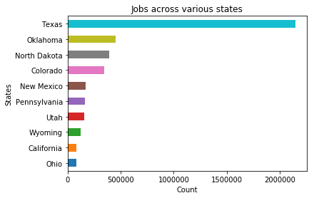

```python
# Plotting the top 10 states for which Hydraulic Fracturing was carried out

df_ffr['DerivedStateName'].value_counts()[:10].sort_values(ascending=True).plot(kind='barh',
                                            align='center', title='Jobs across various states')
plt.xlabel("Count")
plt.ylabel("States")

plt.show()
```

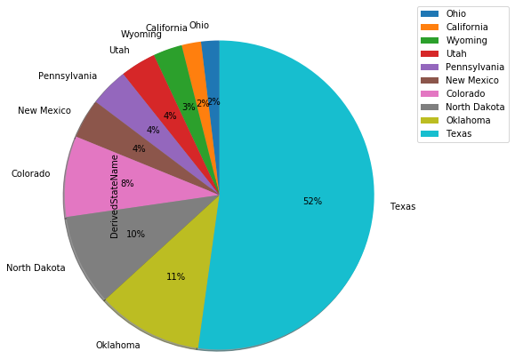

```python
# Percentage wise ploting the same data as above using a pie chart

df_ffr['DerivedStateName'].value_counts()[:10].sort_values(ascending=True).plot(kind='pie',
                                            startangle = 90, shadow = True, autopct='%1.0f%%', radius = 2,
                                            y='Statewise Jobs Contracted')
plt.legend(loc='best', bbox_to_anchor=(1.5, 1.5))
plt.show()
```

### Most Frequently Contracted Suppliers for Fracturing jobs

Now we will find out which suppliers were most frequently contracted.  
The Supplier data needed to be cleansed because punctuations, white spaces and case diffrence caused duplicate entries.  
We will finally plot a pie chart to find out which suppliers were mostly contracted.

```python
# Cleaning the Supplier data

df_ffr_copy = pd.DataFrame()

df_ffr_copy['Supplier'] = df_ffr['Supplier'].str.lower()
df_ffr_copy['Supplier'] = df_ffr_copy['Supplier'].replace("?","")
df_ffr_copy['Supplier'] = df_ffr_copy['Supplier'].str.strip()
df_ffr_copy['Supplier'] = df_ffr_copy['Supplier'].str.replace(r'[^\w\s]', '')

df_ffr['Supplier'] = df_ffr_copy['Supplier']
```

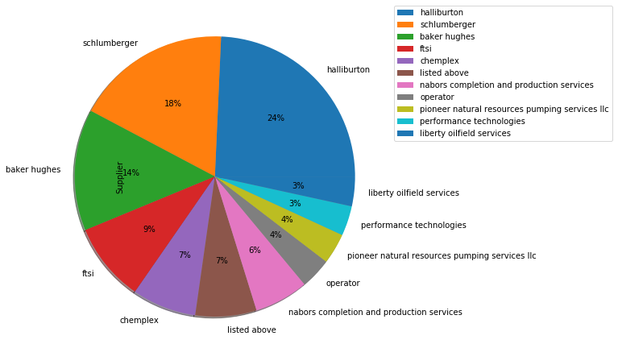

```python
# Plotting pie chart for Suppliers that were contracted more than 50,000 times

df_ffr['Supplier'].value_counts()[df_ffr['Supplier'].value_counts()>50000].plot(kind='pie',
                                                startangle = 0, shadow = True, autopct='%1.0f%%', radius = 2)
plt.legend(loc='best', bbox_to_anchor=(1.5, 1.5))
plt.show()
```

### Time Analysis across some Registries

Now we will determine what were the minimum and maximum start dates and the end dates of these jobs.  
These times were calculated based on individual registries for faster data processing because converting a column to datetime takes a lot of time. However, with better GPUs, this can be done at a faster pace even on the entire dataset.

```python
# Displaying Minimum and Maximum Start and End dates for Registry 1 data

print("Registry 1 - Job StartDate Max - ", pd.to_datetime(df_ffr1['JobStartDate']).max())
print("Registry 1 - Job StartDate Min - ", pd.to_datetime(df_ffr1['JobStartDate']).min())
print("Registry 1 - Job EndDate Max - ", pd.to_datetime(df_ffr1['JobEndDate']).max())
print("Registry 1 - Job EndDate Min - ", pd.to_datetime(df_ffr1['JobEndDate']).min())
```

```
Registry 1 - Job StartDate Max -  2013-04-23 00:00:00
Registry 1 - Job StartDate Min -  1955-05-01 00:00:00
Registry 1 - Job EndDate Max -  2013-04-23 00:00:00
Registry 1 - Job EndDate Min -  1955-05-01 00:00:00
```

```python
# Displaying Minimum and Maximum Start and End dates for Registry 2 data

print("Registry 2 - Job StartDate Min - ", pd.to_datetime(df_ffr2['JobStartDate']).min())
print("Registry 2 - Job StartDate Max - ", pd.to_datetime(df_ffr2['JobStartDate']).max())
print("Registry 2 - Job EndDate Min - ", pd.to_datetime(df_ffr2['JobEndDate']).min())
print("Registry 2 - Job EndDate Max - ", pd.to_datetime(df_ffr2['JobEndDate']).max())
```

```
Registry 2 - Job StartDate Min -  2011-02-04 06:00:00
Registry 2 - Job StartDate Max -  2013-07-24 00:00:00
Registry 2 - Job EndDate Min -  2013-04-23 00:00:00
Registry 2 - Job EndDate Max -  2013-07-24 00:00:00
```

```python
# Displaying Minimum and Maximum Start and End dates for Registry 17 data

print("Registry 17 - Job StartDate Min - ", pd.to_datetime(df_ffr17['JobStartDate']).min())
print("Registry 17 - Job StartDate Max - ", pd.to_datetime(df_ffr17['JobStartDate']).max())
print("Registry 17 - Job EndDate Min - ", pd.to_datetime(df_ffr17['JobEndDate']).min())
print("Registry 17 - Job EndDate Max - ", pd.to_datetime(df_ffr17['JobEndDate']).max())
```

```
Registry 17 - Job StartDate Min -  2008-10-07 06:57:00
Registry 17 - Job StartDate Max -  2019-01-22 00:00:00
Registry 17 - Job EndDate Min -  2018-08-06 05:00:00
Registry 17 - Job EndDate Max -  2019-01-22 06:00:00
```

```python
# Calculating difference in dates by converting default format of Job Start and End dates to datetime
# and then subtracting Job end date from job start date

df_ffr1['DiffernceInDates'] = pd.to_datetime(df_ffr1['JobEndDate']) - pd.to_datetime(df_ffr1['JobStartDate'])
```

```python
df_ffr1.DiffernceInDates.describe()
```

```
count                     250000
mean      3 days 20:59:28.410676
std      23 days 07:40:37.483715
min              0 days 00:00:00
25%              0 days 00:00:00
50%              0 days 00:00:00
75%              3 days 00:00:00
max            618 days 00:00:00
Name: DiffernceInDates, dtype: object
```

```python
df_ffr1[df_ffr1['DiffernceInDates'] == df_ffr1.DiffernceInDates.max()]
```

|  | UploadKey | JobStartDate | JobEndDate | APINumber | StateNumber | CountyNumber | OperatorName | WellName | Latitude | Longitude | ... | IngredientName | CASNumber | PercentHighAdditive | PercentHFJob | IngredientComment | IngredientMSDS | MassIngredient | ClaimantCompany | DisclosureKey | DiffernceInDates |
| --- | --- | --- | --- | --- | --- | --- | --- | --- | --- | --- | --- | --- | --- | --- | --- | --- | --- | --- | --- | --- | --- |
| 153113 | ae3be96b-277a-449e-bce5-c20ef59e0972 | 5/17/2011 12:00:00 AM | 1/24/2013 12:00:00 AM | 4111220820000 | 4 | 111 | Aera Energy LLC | Taylor 836 | 34.31222 | -119.31661 | ... | Potassium Hydroxide | 1310-58-3 | 1.00 | 0.001751 | SmartCare Product | True | 23.9232 | NaN | ae3be96b-277a-449e-bce5-c20ef59e0972 | 618 days |
| 153114 | ae3be96b-277a-449e-bce5-c20ef59e0972 | 5/17/2011 12:00:00 AM | 1/24/2013 12:00:00 AM | 4111220820000 | 4 | 111 | Aera Energy LLC | Taylor 836 | 34.31222 | -119.31661 | ... | Water | 7732-18-5 | 60.00 | 0.105035 | SmartCare Product | True | 1435.3920 | NaN | ae3be96b-277a-449e-bce5-c20ef59e0972 | 618 days |
| 153115 | ae3be96b-277a-449e-bce5-c20ef59e0972 | 5/17/2011 12:00:00 AM | 1/24/2013 12:00:00 AM | 4111220820000 | 4 | 111 | Aera Energy LLC | Taylor 836 | 34.31222 | -119.31661 | ... | Potassium Carbonate | 584-08-7 | 60.00 | 0.162284 | SmartCare Product | True | 2217.7456 | NaN | ae3be96b-277a-449e-bce5-c20ef59e0972 | 618 days |
| 153116 | ae3be96b-277a-449e-bce5-c20ef59e0972 | 5/17/2011 12:00:00 AM | 1/24/2013 12:00:00 AM | 4111220820000 | 4 | 111 | Aera Energy LLC | Taylor 836 | 34.31222 | -119.31661 | ... | Hexamethylenetetramine | 100-97-0 | 0.01 | 0.001685 | NaN | True | 23.0300 | NaN | ae3be96b-277a-449e-bce5-c20ef59e0972 | 618 days |
| 153117 | ae3be96b-277a-449e-bce5-c20ef59e0972 | 5/17/2011 12:00:00 AM | 1/24/2013 12:00:00 AM | 4111220820000 | 4 | 111 | Aera Energy LLC | Taylor 836 | 34.31222 | -119.31661 | ... | P/F Resin | 9003-35-4 | 5.00 | 0.842614 | NaN | True | 11515.0000 | NaN | ae3be96b-277a-449e-bce5-c20ef59e0972 | 618 days |
| 153118 | ae3be96b-277a-449e-bce5-c20ef59e0972 | 5/17/2011 12:00:00 AM | 1/24/2013 12:00:00 AM | 4111220820000 | 4 | 111 | Aera Energy LLC | Taylor 836 | 34.31222 | -119.31661 | ... | Silicon Dioxide (Silica Sand) | 14808-60-7 | 97.00 | 16.346709 | NaN | True | 223391.0000 | NaN | ae3be96b-277a-449e-bce5-c20ef59e0972 | 618 days |
| 153119 | ae3be96b-277a-449e-bce5-c20ef59e0972 | 5/17/2011 12:00:00 AM | 1/24/2013 12:00:00 AM | 4111220820000 | 4 | 111 | Aera Energy LLC | Taylor 836 | 34.31222 | -119.31661 | ... | Hemicellulase Enzyme Concentrate | 9025-56-3 | 3.00 | 0.003185 | NaN | True | 43.5233 | NaN | ae3be96b-277a-449e-bce5-c20ef59e0972 | 618 days |
| 153120 | ae3be96b-277a-449e-bce5-c20ef59e0972 | 5/17/2011 12:00:00 AM | 1/24/2013 12:00:00 AM | 4111220820000 | 4 | 111 | Aera Energy LLC | Taylor 836 | 34.31222 | -119.31661 | ... | Water | 7732-18-5 | 97.00 | 0.102976 | NaN | True | 1407.2539 | NaN | ae3be96b-277a-449e-bce5-c20ef59e0972 | 618 days |
| 153121 | ae3be96b-277a-449e-bce5-c20ef59e0972 | 5/17/2011 12:00:00 AM | 1/24/2013 12:00:00 AM | 4111220820000 | 4 | 111 | Aera Energy LLC | Taylor 836 | 34.31222 | -119.31661 | ... | Contains non-hazardous ingredents which are li... | NaN | 100.00 | 0.133616 | SmartCare Product | True | 1825.9782 | NaN | ae3be96b-277a-449e-bce5-c20ef59e0972 | 618 days |
| 153122 | ae3be96b-277a-449e-bce5-c20ef59e0972 | 5/17/2011 12:00:00 AM | 1/24/2013 12:00:00 AM | 4111220820000 | 4 | 111 | Aera Energy LLC | Taylor 836 | 34.31222 | -119.31661 | ... | Crystalline Silica: Quartz | 14808-60-7 | 1.00 | 0.000238 | NaN | True | 3.2500 | NaN | ae3be96b-277a-449e-bce5-c20ef59e0972 | 618 days |
| 153123 | ae3be96b-277a-449e-bce5-c20ef59e0972 | 5/17/2011 12:00:00 AM | 1/24/2013 12:00:00 AM | 4111220820000 | 4 | 111 | Aera Energy LLC | Taylor 836 | 34.31222 | -119.31661 | ... | Ethylene Glycol | 107-21-1 | 1.00 | 0.000238 | NaN | True | 3.2500 | NaN | ae3be96b-277a-449e-bce5-c20ef59e0972 | 618 days |
| 153124 | ae3be96b-277a-449e-bce5-c20ef59e0972 | 5/17/2011 12:00:00 AM | 1/24/2013 12:00:00 AM | 4111220820000 | 4 | 111 | Aera Energy LLC | Taylor 836 | 34.31222 | -119.31661 | ... | Acid Phosphate Ester | 9046-01-9 | 10.00 | 0.002378 | NaN | True | 32.5000 | NaN | ae3be96b-277a-449e-bce5-c20ef59e0972 | 618 days |
| 153125 | ae3be96b-277a-449e-bce5-c20ef59e0972 | 5/17/2011 12:00:00 AM | 1/24/2013 12:00:00 AM | 4111220820000 | 4 | 111 | Aera Energy LLC | Taylor 836 | 34.31222 | -119.31661 | ... | Quaternary Ammonium Compound | 61789-71-7 | 30.00 | 0.007135 | NaN | True | 97.5000 | NaN | ae3be96b-277a-449e-bce5-c20ef59e0972 | 618 days |
| 153126 | ae3be96b-277a-449e-bce5-c20ef59e0972 | 5/17/2011 12:00:00 AM | 1/24/2013 12:00:00 AM | 4111220820000 | 4 | 111 | Aera Energy LLC | Taylor 836 | 34.31222 | -119.31661 | ... | Phosphonic Acid | 13598-36-2 | 1.00 | 0.000256 | SmartCare Product | True | 3.5000 | NaN | ae3be96b-277a-449e-bce5-c20ef59e0972 | 618 days |
| 153127 | ae3be96b-277a-449e-bce5-c20ef59e0972 | 5/17/2011 12:00:00 AM | 1/24/2013 12:00:00 AM | 4111220820000 | 4 | 111 | Aera Energy LLC | Taylor 836 | 34.31222 | -119.31661 | ... | Crystalline Silica: Quartz (SiO2) | 14808-60-7 | 1.00 | 0.000256 | SmartCare Product | True | 3.5000 | NaN | ae3be96b-277a-449e-bce5-c20ef59e0972 | 618 days |
| 153128 | ae3be96b-277a-449e-bce5-c20ef59e0972 | 5/17/2011 12:00:00 AM | 1/24/2013 12:00:00 AM | 4111220820000 | 4 | 111 | Aera Energy LLC | Taylor 836 | 34.31222 | -119.31661 | ... | Amino Alkyl Phosphonic Acid | Trade Secret | 30.00 | 0.007683 | SmartCare Product | True | 105.0000 | NaN | ae3be96b-277a-449e-bce5-c20ef59e0972 | 618 days |
| 153129 | ae3be96b-277a-449e-bce5-c20ef59e0972 | 5/17/2011 12:00:00 AM | 1/24/2013 12:00:00 AM | 4111220820000 | 4 | 111 | Aera Energy LLC | Taylor 836 | 34.31222 | -119.31661 | ... | Diatomaceous Earth, Calcined | 91053-39-3 | 100.00 | 0.025611 | SmartCare Product | True | 350.0000 | NaN | ae3be96b-277a-449e-bce5-c20ef59e0972 | 618 days |
| 153130 | ae3be96b-277a-449e-bce5-c20ef59e0972 | 5/17/2011 12:00:00 AM | 1/24/2013 12:00:00 AM | 4111220820000 | 4 | 111 | Aera Energy LLC | Taylor 836 | 34.31222 | -119.31661 | ... | Crystalline Silica: Cristobalite | 14464-46-1 | 1.00 | 0.000066 | NaN | True | 0.9000 | NaN | ae3be96b-277a-449e-bce5-c20ef59e0972 | 618 days |
| 153131 | ae3be96b-277a-449e-bce5-c20ef59e0972 | 5/17/2011 12:00:00 AM | 1/24/2013 12:00:00 AM | 4111220820000 | 4 | 111 | Aera Energy LLC | Taylor 836 | 34.31222 | -119.31661 | ... | Crystalline Silica: Quartz (SiO2) | 14808-60-7 | 1.00 | 0.000066 | NaN | True | 0.9000 | NaN | ae3be96b-277a-449e-bce5-c20ef59e0972 | 618 days |
| 153132 | ae3be96b-277a-449e-bce5-c20ef59e0972 | 5/17/2011 12:00:00 AM | 1/24/2013 12:00:00 AM | 4111220820000 | 4 | 111 | Aera Energy LLC | Taylor 836 | 34.31222 | -119.31661 | ... | Magnesium Chloride | 7786-30-3 | 5.00 | 0.000329 | NaN | True | 4.5000 | NaN | ae3be96b-277a-449e-bce5-c20ef59e0972 | 618 days |
| 153133 | ae3be96b-277a-449e-bce5-c20ef59e0972 | 5/17/2011 12:00:00 AM | 1/24/2013 12:00:00 AM | 4111220820000 | 4 | 111 | Aera Energy LLC | Taylor 836 | 34.31222 | -119.31661 | ... | 2-Methyl-4-Isothiazolin-3-One | 2682-20-4 | 5.00 | 0.000329 | NaN | True | 4.5000 | NaN | ae3be96b-277a-449e-bce5-c20ef59e0972 | 618 days |
| 153134 | ae3be96b-277a-449e-bce5-c20ef59e0972 | 5/17/2011 12:00:00 AM | 1/24/2013 12:00:00 AM | 4111220820000 | 4 | 111 | Aera Energy LLC | Taylor 836 | 34.31222 | -119.31661 | ... | 5-Chloro-2-Methyl-4-Isothiazolin-3-One | 26172-55-4 | 10.00 | 0.000659 | NaN | True | 9.0000 | NaN | ae3be96b-277a-449e-bce5-c20ef59e0972 | 618 days |
| 153135 | ae3be96b-277a-449e-bce5-c20ef59e0972 | 5/17/2011 12:00:00 AM | 1/24/2013 12:00:00 AM | 4111220820000 | 4 | 111 | Aera Energy LLC | Taylor 836 | 34.31222 | -119.31661 | ... | Magnesium Nitrate | 10377-60-3 | 10.00 | 0.000659 | NaN | True | 9.0000 | NaN | ae3be96b-277a-449e-bce5-c20ef59e0972 | 618 days |
| 153136 | ae3be96b-277a-449e-bce5-c20ef59e0972 | 5/17/2011 12:00:00 AM | 1/24/2013 12:00:00 AM | 4111220820000 | 4 | 111 | Aera Energy LLC | Taylor 836 | 34.31222 | -119.31661 | ... | Diatomaceous Earth, Calcined | 91053-39-3 | 60.00 | 0.003952 | NaN | True | 54.0000 | NaN | ae3be96b-277a-449e-bce5-c20ef59e0972 | 618 days |
| 153137 | ae3be96b-277a-449e-bce5-c20ef59e0972 | 5/17/2011 12:00:00 AM | 1/24/2013 12:00:00 AM | 4111220820000 | 4 | 111 | Aera Energy LLC | Taylor 836 | 34.31222 | -119.31661 | ... | Ammonium Persulfate | 7727-54-0 | 100.00 | 0.002561 | SmartCare Product | True | 35.0000 | NaN | ae3be96b-277a-449e-bce5-c20ef59e0972 | 618 days |
| 153138 | ae3be96b-277a-449e-bce5-c20ef59e0972 | 5/17/2011 12:00:00 AM | 1/24/2013 12:00:00 AM | 4111220820000 | 4 | 111 | Aera Energy LLC | Taylor 836 | 34.31222 | -119.31661 | ... | Ammonium persulphate | 7727-54-0 | 100.00 | 0.012440 | SmartCare Product | True | 170.0000 | NaN | ae3be96b-277a-449e-bce5-c20ef59e0972 | 618 days |
| 153139 | ae3be96b-277a-449e-bce5-c20ef59e0972 | 5/17/2011 12:00:00 AM | 1/24/2013 12:00:00 AM | 4111220820000 | 4 | 111 | Aera Energy LLC | Taylor 836 | 34.31222 | -119.31661 | ... | Boric Oxide | 1303-86-2 | 20.00 | 0.006911 | NaN | True | 94.4390 | NaN | ae3be96b-277a-449e-bce5-c20ef59e0972 | 618 days |
| 153140 | ae3be96b-277a-449e-bce5-c20ef59e0972 | 5/17/2011 12:00:00 AM | 1/24/2013 12:00:00 AM | 4111220820000 | 4 | 111 | Aera Energy LLC | Taylor 836 | 34.31222 | -119.31661 | ... | Methanol | 67-56-1 | 90.00 | 0.031098 | NaN | True | 424.9757 | NaN | ae3be96b-277a-449e-bce5-c20ef59e0972 | 618 days |
| 153141 | ae3be96b-277a-449e-bce5-c20ef59e0972 | 5/17/2011 12:00:00 AM | 1/24/2013 12:00:00 AM | 4111220820000 | 4 | 111 | Aera Energy LLC | Taylor 836 | 34.31222 | -119.31661 | ... | 2-Butoxyethanol | 111-76-2 | 5.00 | 0.003386 | NaN | True | 46.2748 | NaN | ae3be96b-277a-449e-bce5-c20ef59e0972 | 618 days |
| 153142 | ae3be96b-277a-449e-bce5-c20ef59e0972 | 5/17/2011 12:00:00 AM | 1/24/2013 12:00:00 AM | 4111220820000 | 4 | 111 | Aera Energy LLC | Taylor 836 | 34.31222 | -119.31661 | ... | Methanol | 67-56-1 | 30.00 | 0.020317 | NaN | True | 277.6487 | NaN | ae3be96b-277a-449e-bce5-c20ef59e0972 | 618 days |
| ... | ... | ... | ... | ... | ... | ... | ... | ... | ... | ... | ... | ... | ... | ... | ... | ... | ... | ... | ... | ... | ... |
| 153146 | ae3be96b-277a-449e-bce5-c20ef59e0972 | 5/17/2011 12:00:00 AM | 1/24/2013 12:00:00 AM | 4111220820000 | 4 | 111 | Aera Energy LLC | Taylor 836 | 34.31222 | -119.31661 | ... | Boric Acid | 10043-35-3 | 30.00 | 0.015580 | NaN | True | 212.9100 | NaN | ae3be96b-277a-449e-bce5-c20ef59e0972 | 618 days |
| 153147 | ae3be96b-277a-449e-bce5-c20ef59e0972 | 5/17/2011 12:00:00 AM | 1/24/2013 12:00:00 AM | 4111220820000 | 4 | 111 | Aera Energy LLC | Taylor 836 | 34.31222 | -119.31661 | ... | Methyl Borate | 121-43-7 | 30.00 | 0.015580 | NaN | True | 212.9100 | NaN | ae3be96b-277a-449e-bce5-c20ef59e0972 | 618 days |
| 153148 | ae3be96b-277a-449e-bce5-c20ef59e0972 | 5/17/2011 12:00:00 AM | 1/24/2013 12:00:00 AM | 4111220820000 | 4 | 111 | Aera Energy LLC | Taylor 836 | 34.31222 | -119.31661 | ... | Methanol | 67-56-1 | 60.00 | 0.031160 | NaN | True | 425.8200 | NaN | ae3be96b-277a-449e-bce5-c20ef59e0972 | 618 days |
| 153149 | ae3be96b-277a-449e-bce5-c20ef59e0972 | 5/17/2011 12:00:00 AM | 1/24/2013 12:00:00 AM | 4111220820000 | 4 | 111 | Aera Energy LLC | Taylor 836 | 34.31222 | -119.31661 | ... | Methanol | 67-56-1 | 30.00 | 0.025369 | SmartCare Product | True | 346.6856 | NaN | ae3be96b-277a-449e-bce5-c20ef59e0972 | 618 days |
| 153150 | ae3be96b-277a-449e-bce5-c20ef59e0972 | 5/17/2011 12:00:00 AM | 1/24/2013 12:00:00 AM | 4111220820000 | 4 | 111 | Aera Energy LLC | Taylor 836 | 34.31222 | -119.31661 | ... | Water | 7732-18-5 | 50.00 | 0.042281 | SmartCare Product | True | 577.8094 | NaN | ae3be96b-277a-449e-bce5-c20ef59e0972 | 618 days |
| 153151 | ae3be96b-277a-449e-bce5-c20ef59e0972 | 5/17/2011 12:00:00 AM | 1/24/2013 12:00:00 AM | 4111220820000 | 4 | 111 | Aera Energy LLC | Taylor 836 | 34.31222 | -119.31661 | ... | Mixture of Surfactants | Trade Secret | 60.00 | 0.050738 | SmartCare Product | True | 693.3713 | NaN | ae3be96b-277a-449e-bce5-c20ef59e0972 | 618 days |
| 153152 | ae3be96b-277a-449e-bce5-c20ef59e0972 | 5/17/2011 12:00:00 AM | 1/24/2013 12:00:00 AM | 4111220820000 | 4 | 111 | Aera Energy LLC | Taylor 836 | 34.31222 | -119.31661 | ... | Methanol | 67-56-1 | 50.00 | 0.361748 | NaN | True | 4943.5820 | NaN | ae3be96b-277a-449e-bce5-c20ef59e0972 | 618 days |
| 153153 | ae3be96b-277a-449e-bce5-c20ef59e0972 | 5/17/2011 12:00:00 AM | 1/24/2013 12:00:00 AM | 4111220820000 | 4 | 111 | Aera Energy LLC | Taylor 836 | 34.31222 | -119.31661 | ... | Poly (Oxyethylene) Nonylphenol Ether | 9016-45-9 | 50.00 | 0.361748 | NaN | True | 4943.5820 | NaN | ae3be96b-277a-449e-bce5-c20ef59e0972 | 618 days |
| 153154 | ae3be96b-277a-449e-bce5-c20ef59e0972 | 5/17/2011 12:00:00 AM | 1/24/2013 12:00:00 AM | 4111220820000 | 4 | 111 | Aera Energy LLC | Taylor 836 | 34.31222 | -119.31661 | ... | 1-butoxy-2-propanol | 5131-66-8 | 5.00 | 0.023040 | SmartCare Product | True | 314.8530 | NaN | ae3be96b-277a-449e-bce5-c20ef59e0972 | 618 days |
| 153155 | ae3be96b-277a-449e-bce5-c20ef59e0972 | 5/17/2011 12:00:00 AM | 1/24/2013 12:00:00 AM | 4111220820000 | 4 | 111 | Aera Energy LLC | Taylor 836 | 34.31222 | -119.31661 | ... | Crystalline Silica: Quartz | 14808-60-7 | 5.00 | 0.023040 | SmartCare Product | True | 314.8530 | NaN | ae3be96b-277a-449e-bce5-c20ef59e0972 | 618 days |
| 153156 | ae3be96b-277a-449e-bce5-c20ef59e0972 | 5/17/2011 12:00:00 AM | 1/24/2013 12:00:00 AM | 4111220820000 | 4 | 111 | Aera Energy LLC | Taylor 836 | 34.31222 | -119.31661 | ... | Isotridecanol, ethoxylated | 9043-30-5 | 5.00 | 0.023040 | SmartCare Product | True | 314.8530 | NaN | ae3be96b-277a-449e-bce5-c20ef59e0972 | 618 days |
| 153157 | ae3be96b-277a-449e-bce5-c20ef59e0972 | 5/17/2011 12:00:00 AM | 1/24/2013 12:00:00 AM | 4111220820000 | 4 | 111 | Aera Energy LLC | Taylor 836 | 34.31222 | -119.31661 | ... | Paraffinic Petroleum Distillate | 64742-55-8 | 30.00 | 0.138237 | SmartCare Product | True | 1889.1180 | NaN | ae3be96b-277a-449e-bce5-c20ef59e0972 | 618 days |
| 153158 | ae3be96b-277a-449e-bce5-c20ef59e0972 | 5/17/2011 12:00:00 AM | 1/24/2013 12:00:00 AM | 4111220820000 | 4 | 111 | Aera Energy LLC | Taylor 836 | 34.31222 | -119.31661 | ... | Petroleum Distillates | 64742-47-8 | 30.00 | 0.138237 | SmartCare Product | True | 1889.1180 | NaN | ae3be96b-277a-449e-bce5-c20ef59e0972 | 618 days |
| 153159 | ae3be96b-277a-449e-bce5-c20ef59e0972 | 5/17/2011 12:00:00 AM | 1/24/2013 12:00:00 AM | 4111220820000 | 4 | 111 | Aera Energy LLC | Taylor 836 | 34.31222 | -119.31661 | ... | Petroleum Distillate Blend | Trade Secret | 70.00 | 0.315639 | SmartCare Product | True | 4313.4673 | NaN | ae3be96b-277a-449e-bce5-c20ef59e0972 | 618 days |
| 153160 | ae3be96b-277a-449e-bce5-c20ef59e0972 | 5/17/2011 12:00:00 AM | 1/24/2013 12:00:00 AM | 4111220820000 | 4 | 111 | Aera Energy LLC | Taylor 836 | 34.31222 | -119.31661 | ... | Guar Gum | 9000-30-0 | 60.00 | 0.456839 | SmartCare Product | True | 6243.0745 | NaN | ae3be96b-277a-449e-bce5-c20ef59e0972 | 618 days |
| 153161 | ae3be96b-277a-449e-bce5-c20ef59e0972 | 5/17/2011 12:00:00 AM | 1/24/2013 12:00:00 AM | 4111220820000 | 4 | 111 | Aera Energy LLC | Taylor 836 | 34.31222 | -119.31661 | ... | Ethylene Glycol Monobutyl Ether | 111-76-2 | 0.00 | 0.000000 | NaN | False | 0.0000 | NaN | ae3be96b-277a-449e-bce5-c20ef59e0972 | 618 days |
| 153162 | ae3be96b-277a-449e-bce5-c20ef59e0972 | 5/17/2011 12:00:00 AM | 1/24/2013 12:00:00 AM | 4111220820000 | 4 | 111 | Aera Energy LLC | Taylor 836 | 34.31222 | -119.31661 | ... | Quaternary Ammonium Compounds bis[Hydrogenated... | 68953-58-2 | 0.00 | 0.000000 | NaN | False | 0.0000 | NaN | ae3be96b-277a-449e-bce5-c20ef59e0972 | 618 days |
| 153163 | ae3be96b-277a-449e-bce5-c20ef59e0972 | 5/17/2011 12:00:00 AM | 1/24/2013 12:00:00 AM | 4111220820000 | 4 | 111 | Aera Energy LLC | Taylor 836 | 34.31222 | -119.31661 | ... | Crystalline Silica | 14808-60-7 | 0.00 | 0.000000 | NaN | False | 0.0000 | NaN | ae3be96b-277a-449e-bce5-c20ef59e0972 | 618 days |
| 153164 | ae3be96b-277a-449e-bce5-c20ef59e0972 | 5/17/2011 12:00:00 AM | 1/24/2013 12:00:00 AM | 4111220820000 | 4 | 111 | Aera Energy LLC | Taylor 836 | 34.31222 | -119.31661 | ... | Poly (oxy-1,2-ethanediyl) | 24938-91-8 | 0.00 | 0.000000 | NaN | False | 0.0000 | NaN | ae3be96b-277a-449e-bce5-c20ef59e0972 | 618 days |
| 153165 | ae3be96b-277a-449e-bce5-c20ef59e0972 | 5/17/2011 12:00:00 AM | 1/24/2013 12:00:00 AM | 4111220820000 | 4 | 111 | Aera Energy LLC | Taylor 836 | 34.31222 | -119.31661 | ... | 2-butoxy-1-propanol | 15821-83-7 | 0.00 | 0.000461 | NaN | False | 6.2971 | NaN | ae3be96b-277a-449e-bce5-c20ef59e0972 | 618 days |
| 153166 | ae3be96b-277a-449e-bce5-c20ef59e0972 | 5/17/2011 12:00:00 AM | 1/24/2013 12:00:00 AM | 4111220820000 | 4 | 111 | Aera Energy LLC | Taylor 836 | 34.31222 | -119.31661 | ... | Cured Acrylic Resin | Trade Secret | 0.00 | 0.001756 | NaN | False | 24.0000 | NaN | ae3be96b-277a-449e-bce5-c20ef59e0972 | 618 days |
| 153167 | ae3be96b-277a-449e-bce5-c20ef59e0972 | 5/17/2011 12:00:00 AM | 1/24/2013 12:00:00 AM | 4111220820000 | 4 | 111 | Aera Energy LLC | Taylor 836 | 34.31222 | -119.31661 | ... | Aminopropylsilanol | 58160-99-9 | 0.00 | 0.003708 | NaN | False | 50.6730 | NaN | ae3be96b-277a-449e-bce5-c20ef59e0972 | 618 days |
| 153168 | ae3be96b-277a-449e-bce5-c20ef59e0972 | 5/17/2011 12:00:00 AM | 1/24/2013 12:00:00 AM | 4111220820000 | 4 | 111 | Aera Energy LLC | Taylor 836 | 34.31222 | -119.31661 | ... | Hemicellulase Enzyme Concentrate | 9025-56-3 | 0.00 | 0.004008 | NaN | False | 54.7793 | NaN | ae3be96b-277a-449e-bce5-c20ef59e0972 | 618 days |
| 153169 | ae3be96b-277a-449e-bce5-c20ef59e0972 | 5/17/2011 12:00:00 AM | 1/24/2013 12:00:00 AM | 4111220820000 | 4 | 111 | Aera Energy LLC | Taylor 836 | 34.31222 | -119.31661 | ... | Aminopropylsilsesquioxanes | 68400-07-7 | 0.00 | 0.022248 | NaN | False | 304.0380 | NaN | ae3be96b-277a-449e-bce5-c20ef59e0972 | 618 days |
| 153170 | ae3be96b-277a-449e-bce5-c20ef59e0972 | 5/17/2011 12:00:00 AM | 1/24/2013 12:00:00 AM | 4111220820000 | 4 | 111 | Aera Energy LLC | Taylor 836 | 34.31222 | -119.31661 | ... | Water | 7732-18-5 | 0.00 | 0.251175 | NaN | False | 3432.5059 | NaN | ae3be96b-277a-449e-bce5-c20ef59e0972 | 618 days |
| 153171 | ae3be96b-277a-449e-bce5-c20ef59e0972 | 5/17/2011 12:00:00 AM | 1/24/2013 12:00:00 AM | 4111220820000 | 4 | 111 | Aera Energy LLC | Taylor 836 | 34.31222 | -119.31661 | ... | Hexamethylenetetramine | 1009-7-0 | 0.01 | 0.002893 | NaN | True | 39.5420 | NaN | ae3be96b-277a-449e-bce5-c20ef59e0972 | 618 days |
| 153172 | ae3be96b-277a-449e-bce5-c20ef59e0972 | 5/17/2011 12:00:00 AM | 1/24/2013 12:00:00 AM | 4111220820000 | 4 | 111 | Aera Energy LLC | Taylor 836 | 34.31222 | -119.31661 | ... | P/F Resin | 9003-35-4 | 5.00 | 1.446749 | NaN | True | 19771.0000 | NaN | ae3be96b-277a-449e-bce5-c20ef59e0972 | 618 days |
| 153173 | ae3be96b-277a-449e-bce5-c20ef59e0972 | 5/17/2011 12:00:00 AM | 1/24/2013 12:00:00 AM | 4111220820000 | 4 | 111 | Aera Energy LLC | Taylor 836 | 34.31222 | -119.31661 | ... | Silicon Dioxide (Silica Sand) | 14808-60-7 | 97.00 | 28.066938 | NaN | True | 383557.4000 | NaN | ae3be96b-277a-449e-bce5-c20ef59e0972 | 618 days |
| 153174 | ae3be96b-277a-449e-bce5-c20ef59e0972 | 5/17/2011 12:00:00 AM | 1/24/2013 12:00:00 AM | 4111220820000 | 4 | 111 | Aera Energy LLC | Taylor 836 | 34.31222 | -119.31661 | ... | Ethanol | 64-17-5 | 5.00 | 0.006343 | NaN | True | 86.6775 | NaN | ae3be96b-277a-449e-bce5-c20ef59e0972 | 618 days |
| 153175 | ae3be96b-277a-449e-bce5-c20ef59e0972 | 5/17/2011 12:00:00 AM | 1/24/2013 12:00:00 AM | 4111220820000 | 4 | 111 | Aera Energy LLC | Taylor 836 | 34.31222 | -119.31661 | ... | Water | 7732-18-5 | 100.00 | 50.276430 | NaN | True | 687068.0712 | NaN | ae3be96b-277a-449e-bce5-c20ef59e0972 | 618 days |

63 rows × 40 columns

```python
df_ffr1[df_ffr1['DiffernceInDates'] == df_ffr1.DiffernceInDates.max()].TVD.describe()
```

```
count      63.0
mean     5800.0
std         0.0
min      5800.0
25%      5800.0
50%      5800.0
75%      5800.0
max      5800.0
Name: TVD, dtype: float64
```

The difference in dates can also help us understanding using domain knowledge the reason why it takes a majority of the job to be completed in 0 days and why is a job that even took in this Registry data 618 days.

### Plotting all the Federal and Indian Wells using Geopandas

First we will be creating a Geopanda DataFrame from the original dataset and then we will be plotting the Federal and Indian Wells throughout the United States.  
We will then plot bar charts of the most frequently Federal and Indian Wells in which hydraulic fracturing is carried out.

```python
# Creating a Geopanda dataframe similar to that of the combined dataset

%matplotlib inline

geometry = [Point(xy) for xy in zip(df_ffr.Longitude, df_ffr.Latitude)]
crs = {'init': 'epsg:4326'}
street_map = gpd.read_file('C:\\Users\\range\\FracFocus\\UScounties\\UScounties.shp')

new_locs = gpd.GeoDataFrame(df_ffr, crs=crs, geometry=geometry)
new_locs.head()
```

|  | UploadKey | JobStartDate | JobEndDate | APINumber | StateNumber | CountyNumber | OperatorName | WellName | Latitude | Longitude | ... | CASNumber | PercentHighAdditive | PercentHFJob | IngredientComment | IngredientMSDS | MassIngredient | ClaimantCompany | DisclosureKey | DerivedStateName | geometry |
| --- | --- | --- | --- | --- | --- | --- | --- | --- | --- | --- | --- | --- | --- | --- | --- | --- | --- | --- | --- | --- | --- |
| 0 | 448c1dab-c7fd-4e07-9d6f-e3b1cf64b708 | 5/1/1955 12:00:00 AM | 5/1/1955 12:00:00 AM | 42317372620000 | 42 | 317 | Pioneer Natural Resources | Rogers 42 #5 | 32.283431 | -101.906575 | ... | NaN | NaN | NaN | NaN | NaN | NaN | NaN | NaN | Texas | POINT (-101.9065747 32.28343107) |
| 1 | f66add2e-8ea8-4843-9388-24725b5d37c1 | 5/19/1982 12:00:00 AM | 5/19/1982 12:00:00 AM | 49009219470000 | 49 | 9 | Chesapeake Operating, Inc. | WILLIAM VALENTINE 1 | 42.972810 | -105.953840 | ... | NaN | NaN | NaN | NaN | NaN | NaN | NaN | NaN | Wyoming | POINT (-105.95384 42.97281) |
| 2 | f66add2e-8ea8-4843-9388-24725b5d37c1 | 5/19/1982 12:00:00 AM | 5/19/1982 12:00:00 AM | 49009219470000 | 49 | 9 | Chesapeake Operating, Inc. | WILLIAM VALENTINE 1 | 42.972810 | -105.953840 | ... | NaN | NaN | NaN | NaN | NaN | NaN | NaN | NaN | Wyoming | POINT (-105.95384 42.97281) |
| 3 | 95f0904c-2556-4912-9f5a-34913ba57625 | 2/7/1995 12:00:00 AM | 2/7/1995 12:00:00 AM | 49009228850000 | 49 | 9 | Chesapeake Operating, Inc. | LIZARD HEAD 1-8H RE | 42.851470 | -105.411510 | ... | NaN | NaN | NaN | NaN | NaN | NaN | NaN | NaN | Wyoming | POINT (-105.41151 42.85147) |
| 4 | 95f0904c-2556-4912-9f5a-34913ba57625 | 2/7/1995 12:00:00 AM | 2/7/1995 12:00:00 AM | 49009228850000 | 49 | 9 | Chesapeake Operating, Inc. | LIZARD HEAD 1-8H RE | 42.851470 | -105.411510 | ... | NaN | NaN | NaN | NaN | NaN | NaN | NaN | NaN | Wyoming | POINT (-105.41151 42.85147) |

5 rows × 41 columns

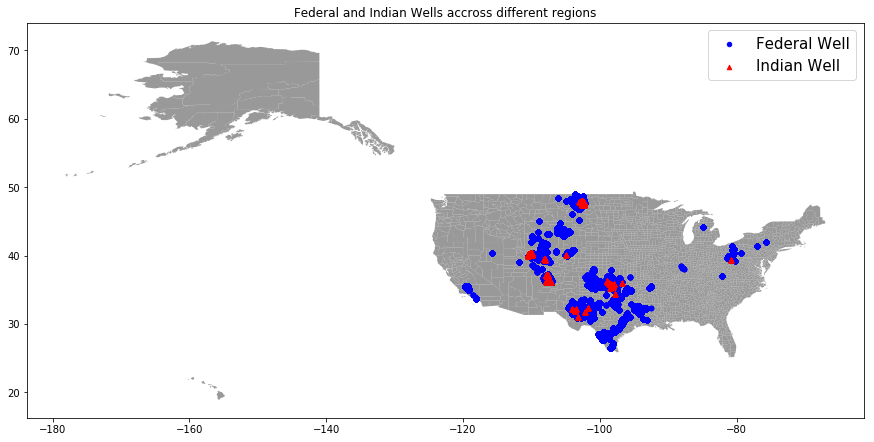

```python
# Plotting the GeoPanda DataFrame with Federal and Indian Wells

fig, ax = plt.subplots(figsize = (15,15))
street_map.plot(ax = ax, alpha = 0.8, color='grey')
new_locs[new_locs['FederalWell']==True].plot(ax=ax, markersize=20, color='blue', marker='o', label='Federal Well')
new_locs[new_locs['IndianWell']==True].plot(ax=ax, markersize=20, color='red', marker='^', label='Indian Well')
plt.title('Federal and Indian Wells accross different regions')
plt.legend(prop={'size': 15})
```

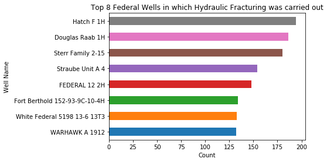

```python
# Plotting a Horizontal Bar Chart of the top frequently Federal wells in which fracturing was carried out

df_ffr.loc[df_ffr['FederalWell'] == True].WellName.value_counts()[df_ffr.loc[df_ffr['FederalWell'] == True].WellName.value_counts()>130].sort_values(ascending=True).plot(kind='barh', title='Top 8 Federal Wells in which Hydraulic Fracturing was carried out')
plt.xlabel("Count")
plt.ylabel("Well Name")

plt.show()
```

```python
# More details about these Federal Wells

df_ffr.loc[df_ffr['FederalWell'] == True].WellName.describe()
```

```
count         295214
unique          7672
top       Hatch F 1H
freq             194
Name: WellName, dtype: object
```

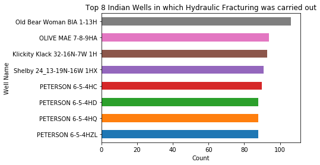

```python
# Plotting a Horizontal Bar Chart of the top frequently Federal wells in which fracturing was carried out

df_ffr.loc[df_ffr['IndianWell'] == True].WellName.value_counts()[df_ffr.loc[df_ffr['IndianWell'] == True].WellName.value_counts()>87].sort_values(ascending=True).plot(kind='barh', title='Top 8 Indian Wells in which Hydraulic Fracturing was carried out')
plt.xlabel("Count")
plt.ylabel("Well Name")

plt.show()
```

```python
# More details about these Indian Wells

df_ffr1.loc[df_ffr1['IndianWell'] == True].WellName.describe()
```

```
count                                 54
unique                                 1
top        Fort Berthold 148-94-22A-27-2
freq                                  54
Name: WellName, dtype: object
```

### Ingredients used across various locations

We will now find out in which locations were some commonly used ingredients used. This will also be done using GeoPandas but only for Registry 1.  
This analysis can be used for rare ingredients to find out where were they used.

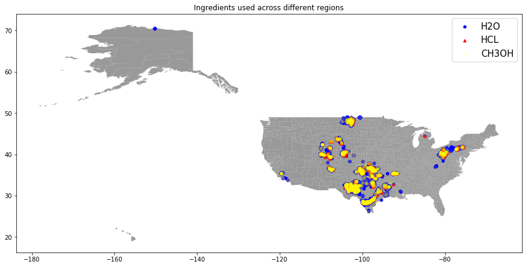

```python
# Creating a Geopanda dataframe similar to that of the combined dataset

geometry = [Point(xy) for xy in zip(df_ffr1.Longitude, df_ffr1.Latitude)]
crs = {'init': 'epsg:4326'}
street_map = gpd.read_file('C:\\Users\\range\\FracFocus\\UScounties\\UScounties.shp')

new_locs = gpd.GeoDataFrame(df_ffr1, crs=crs, geometry=geometry)


# Plotting the GeoPanda DataFrame with some ingredients

fig, ax = plt.subplots(figsize = (15,15))
street_map.plot(ax = ax, alpha = 0.8, color='grey')
new_locs[new_locs['IngredientName']=='Water'].plot(ax=ax, markersize=20, color='blue', marker='o', label='H2O')
new_locs[new_locs['IngredientName']=='Hydrochloric acid'].plot(ax=ax, markersize=20, color='red', marker='^', label='HCL')
new_locs[new_locs['IngredientName']=='Methanol'].plot(ax=ax, markersize=20, color='yellow', marker='o', label='CH3OH', alpha = 0.1)
plt.title('Ingredients used across different regions')
plt.legend(prop={'size': 15})
```

This shows where exactly were these ingredients used.

### Calculation of Volume based on ingredients

```python
# Calculation of volume based on ingredients

def calculate_volume(row):
    if row['IngredientName'] == 'Water':
        return row['TotalBaseWaterVolume'] * row['PercentHFJob']
    else:
        return row['TotalBaseNonWaterVolume'] * row['PercentHFJob']

df_ffr['Volume_by_ingredients'] = 0
df_ffr['Volume_by_ingredients'] = df_ffr.apply(calculate_volume, axis=1)
```

```python
# Viewing the information calculated above

df_ffr.Volume_by_ingredients.describe()
```

```
count    4.075049e+06
mean     1.180399e+07
std      1.316354e+08
min     -1.073138e+08
25%      0.000000e+00
50%      0.000000e+00
75%      0.000000e+00
max      5.920932e+10
Name: Volume_by_ingredients, dtype: float64
```

This can be used to find volumes of individual ingredients that can be used for further analysis.